# VLM Wrong Predictions: attr_decking_material [both_right]

Actual: Timber

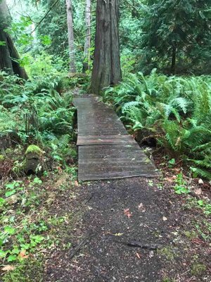

21399__AST_EX_20210911_124304.jpeg

Asset 52469 1 image

Predicted: VLM: Timber | DINOv3: Timber (conf: N/A)

Actual: Timber

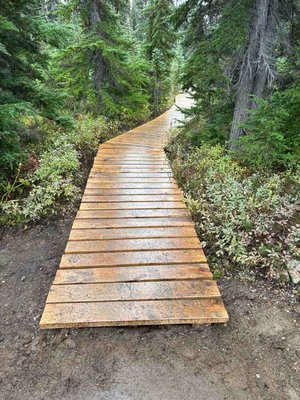

87886__AST_EX_20250914_165603.jpeg

Asset 52245 1 image

Predicted: VLM: Timber | DINOv3: Timber (conf: N/A)

Actual: Timber

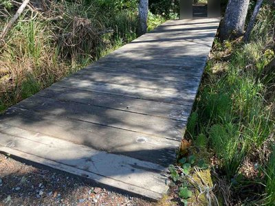

40583__AST_EX_20220510_112627.jpeg

Asset 53556 2 images

Predicted: VLM: Timber | DINOv3: Timber (conf: N/A)

Actual: Timber

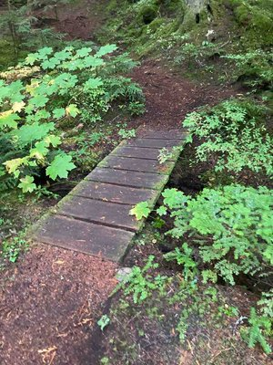

63735__AST_EX_20221004_092847.jpeg

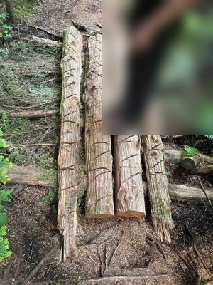

85593__AST_EX_20250720_155517.jpeg

Asset 55645 1 image

Predicted: VLM: Timber | DINOv3: Timber (conf: N/A)

Actual: Timber

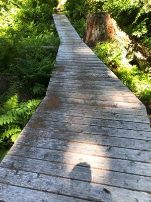

56120__AST_EX_20220725_113102.jpeg

Asset 56209 3 images

Predicted: VLM: Timber | DINOv3: Timber (conf: N/A)

Actual: Timber

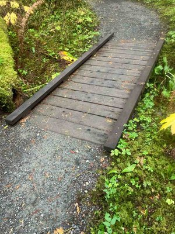

88832__AST_EX_20250928_135750.jpeg

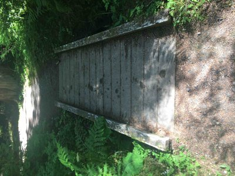

13518__AST_EX_20210812_120624.jpeg

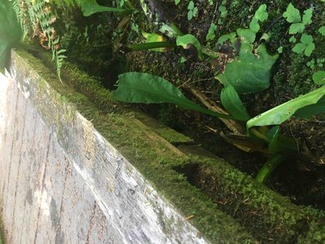

13517__AST_EX_20210812_120655.jpeg

Asset 56345 3 images

Predicted: VLM: Timber | DINOv3: Timber (conf: N/A)

Actual: Timber

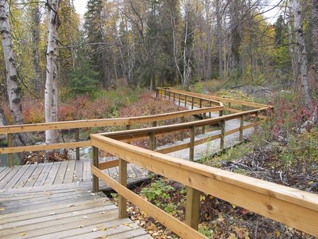

34__IMG_5633.JPG

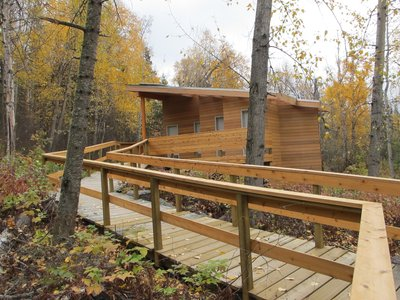

35__IMG_5635.JPG

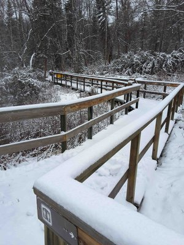

76274__MI_20241027_120942.jpg